# WQP Parameter and Method Harmonization

# Harmonizing disparate data

The data from the water quality portal includes a wide range of methods and characteristic names. For example in the “chlorophyll” this can be chlorophyll a, b, or both and retrieved using a variety of methods. To know which methods and characteristic names to keep and use, we must first get a better understanding of the type of data we have.

Here we are harmonizing the entirety of the water quality portal data even though the vast majority of these sites will not be landsat visible. The computation time to do it for a few extra million samples is not onerous and the intermediate mostly harmonized full dataset will likely be useful for other uses.

```r
#Define a function that renames and reorders columns from the raw files
wqp.renamer <- function(df){
  simple.names <- df %>%
                  dplyr::select(date=ActivityStartDate,
                         parameter=CharacteristicName,
                         units=ResultMeasure.MeasureUnitCode,
                         SiteID=MonitoringLocationIdentifier,
                         org=OrganizationFormalName,
                         org_id=OrganizationIdentifier,
                         time=ActivityStartTime.Time,
                         value=ResultMeasureValue,
                         sample_method=SampleCollectionMethod.MethodName,
                         analytical_method=ResultAnalyticalMethod.MethodName,
                         particle_size=ResultParticleSizeBasisText,
                         date_time=ActivityStartDateTime,
                         media=ActivityMediaName,
                         sample_depth=ActivityDepthHeightMeasure.MeasureValue,
                         sample_depth_unit=ActivityDepthHeightMeasure.MeasureUnitCode,
                         fraction=ResultSampleFractionText,
                         status=ResultStatusIdentifier) %>%
  #Remove trailing white space in labels
  mutate(units = trimws(units)) %>%
  #Keep only samples that are water samples
  filter(media=='Water')
  dropped = nrow(df)-nrow(simple.names)
  print(paste('we dropped',dropped,'samples because the sample medium was not labeled as Water'))
  return(simple.names)
}

#Function for making a nice table that gets a summary of units and the number of observations with that unit code
unit.kable <- function(d){
  d %>%
    group_by(units) %>%
    summarize(count=n()) %>%
    arrange(desc(count)) %>%
    kable(.,'html',caption='All  parameter and unit combinations') %>%
    kable_styling() %>%
    scroll_box(width='500px',height='400px')
}

unit.disharmony <- function(d,lookup){
  d %>%
    anti_join(lookup,by='units') %>%
    group_by(units) %>%
    summarize(count=n())  %>%
    kable(.,'html',caption='The following measurements
          were dropped because the units do not make sense') %>%
    kable_styling() %>%
    scroll_box(width='500px',height='400px')
}

sample.kable <- function(d){
d %>%
  group_by(sample_method) %>%
  summarize(count=n()) %>%
  arrange(desc(count)) %>%
  kable(.,'html',caption='All sample methods and their count') %>%
  kable_styling() %>%
  scroll_box(width='600px',height='400px')
}

analytical.kable <- function(d){
  d %>%
    group_by(analytical_method) %>%
    summarize(count=n()) %>%
    arrange(desc(count)) %>%
    kable(.,'html',caption='All analytical methods and their count') %>%
    kable_styling() %>%
    scroll_box(width='600px',height='400px')
}
```

We’ll start with the easiest first. Secchi depth

# Secchi depth

## Secchi Methods

The nice thing with secchi disk depth methods, is that the name explains the method and their are not really alternative methods so we will not filter this data by sampling or analytical method categories.

## Secchi Unit Harmonization

In many ways, the secchi disk depth measurement is the easiest water quality parameter to harmonize, because there is really only one method for measuring secchi disk depth (it’s in the name after all), and there should always be units of depth (m, ft, inches, cm, etc…). So to harmonize secchi depth measurements we simpy drop all units that are not units of depth and convert all units to a single kind with a lookup table.

First let’s make sure R is starting with a fresh memory clean because these datasets can get clogged. A call to gc() should clear any memory issues from previous scipiper work.

```r
gc()
```

```
##           used (Mb) gc trigger  (Mb) max used (Mb)
## Ncells  937283 50.1    1911875 102.2  1227575 65.6
## Vcells 1592969 12.2    8388608  64.0  2224145 17.0
```

```r
#Read in the raw data from '1_wqdata/out'
secchi <- read_feather('1_wqdata/out/wqp/all_raw_secchi.feather') %>%
  wqp.renamer()
```

```
## [1] "we dropped 3086 samples because the sample medium was not labeled as Water"
```

```r
#Summarize by characteristic name and unit code and print
unit.kable(secchi)
```

All parameter and unit combinations

| units | count |
| --- | --- |
| m | 1890471 |
| ft | 396756 |
| cm | 116759 |
| NA | 61277 |
| in | 56543 |
| None | 847 |
| mg | 587 |
| ft/sec | 20 |
| deg F | 1 |
| mi | 1 |
| NTU | 1 |

### Secchi unit disharmony

Now that we can see all the units we have we can drop non-depth units and make a lookup table to convert all units to meters.

```r
#Create a lookup table of units and conversion factors that we want to keep
secchi.lookup <- tibble(units=c('cm','ft','in','m','mi'),
                        conversion = c(0.01,.3048,0.0254,1,1609.34))

# Do an anti_join to these units so that all units that aren't kept can be highlighted and displayed
unit.disharmony(secchi,secchi.lookup)
```

The following measurements were dropped because the units do not make sense

| units | count |
| --- | --- |
| NA | 61277 |
| deg F | 1 |
| ft/sec | 20 |
| mg | 587 |
| None | 847 |
| NTU | 1 |

### Secchi unit harmony in meters

```r
#Join secchi by unit name and then multiply by conversion factor to get meters
secchi.harmonized <- secchi %>%
  inner_join(secchi.lookup,by='units') %>%
  mutate(harmonized_parameter = 'secchi',
         harmonized_value=value*conversion,
         harmonized_unit='meters')

rm(secchi,secchi.lookup)
```

Next easiest is TSS

# TSS

This [paper](https://water.usgs.gov/osw/pubs/WRIR00-4191.pdf) is really useful for exploring this data. In this paper, the USGS directly compares estimates of Suspended Sediment Concentration (SSC) and Total Suspended Solids (TSS). The primary difference between these methods, as laid out in this paper, is that SSC estimates the mass of suspended solids in a sample volume, by drying out the entire sample without subsampling the water volume. TSS methods often involve some form of subsampling of the total water volume. The paper highlights that while many estimates of TSS and SSC are essentially the same, samples with high sand content show systematic bias in TSS estimates. For our purposes, we have no apriori way to distinguish samples with high or low sand, so we have made the choice to assume that measurements of SSC and TSS are, over the bulk of samples, the same. We use the term “TSS” from here on to describe this data that is both SSC and TSS.

```r
#Read in the raw data from '1_wqdata/out'
tss <- read_feather('1_wqdata/out/wqp/all_raw_tss.feather') %>%
  wqp.renamer()
```

```
## [1] "we dropped 90037 samples because the sample medium was not labeled as Water"
```

```r
#Summarize by characteristic name and unit code
unit.kable(tss)
```

All parameter and unit combinations

| units | count |
| --- | --- |
| mg/l | 4479425 |
| % | 737437 |
| NA | 271606 |
| ppm | 2019 |
| tons/day | 529 |
| ug/l | 476 |
| g | 313 |
| kg | 29 |
| None | 19 |
| count | 1 |
| NTU | 1 |

## TSS methods

Now that we have made the decision to call SSC and TSS interchangeable depsite their slight methodological differences, we need to explore the various methods used to get TSS or SSC concentration estimates. Unlike with issues with units, we can not harmonize our way out of methods that don’t make sense. So instead we will be filtering out these methods.

There are essentially two important methods for thinking about TSS and SSC. The field method used to collect the water sample and the analytical method used to weigh out suspended sediment and total water volume. The sample methods are extremely verbose and varied, but mostly boil down to some version of sample collected in bottle of water. For posterity a table of sample method is reproduced here, but we do not filter based on sample method.

### TSS sample methods

Many of these methods refer to other documents that were used as a protocol for sampling (EPA METHOD or USGS), but these also are versions of collecting water with a bottle, pump, or depth sampling equipment.

```r
sample.kable(tss)
```

All sample methods and their count

| sample_method | count |
| --- | --- |
| USGS | 1683498 |
| Surface | 322707 |
| Grab sample. Submerge and fill a water sampling vessel, or sample directly into the sample bottle provided by the an… | 222465 |
| Grab | 208955 |
| Point sample | 196862 |
| Equal width increment (ewi) | 188011 |
| Water Grab Sampling | 153724 |
| G | 93474 |
| Unknown | 90021 |
| GRAB | 89945 |
| Ambient Water Quality Monitoring QAPP and SOP | 88406 |
| Total Suspended Solids/Volatile Suspended Sample Filtration, Processing & Storage T | 84504 |
| Multiple verticals | 68208 |
| Grab Sample | 67899 |
| GRAB SAMPLE | 56487 |
| SJR-SOP | 54918 |
| Equal discharge increment (edi) | 53147 |
| Total Suspended Solids/Volatile Suspended Sample Filtration, Processing & Storage | 50252 |
| ADEM SOPs-2000 Series-Surface Water | 46812 |
| Water_Grab | 45020 |
| STD_SC | 43049 |
| GRAB | 41867 |
| Grab sample (dip) | 41284 |
| SuspSed; Pumping - stream sample using a pumping mechanism | 40543 |
| Chesapeake Bay Program | 38805 |
| SOP For The Collection And Preservation Of Stream And River Grab Samples For Chemical And Biological Analysis. | 38341 |
| STANDARD | 36280 |
| Water Grab Sample | 35797 |
| OEPA Surface Water Sample Collection Method | 33185 |
| SOP | 31879 |

[output cut: 687 more lines]

### TSS analytical methods

Unlike with secchi disk depth measurements, there are a variety of analytical methods available to measure TSS. Many of these should provide similar results, but some can be used to highlight potential erroeneous data entry (Phosphorous content should not be a method of TSS calculation), but many of them are simply labeled by a state or federal protocol number, making trimming and evaluating these various methods difficult. Below is a table of all possible analytical methods and their count

```r
analytical.kable(tss)
```

All analytical methods and their count

| analytical_method | count |
| --- | --- |
| NA | 2215483 |
| 2540 D ~ Total Suspended Solids in Water | 767063 |
| Non-Filterable Residue - TSS | 691014 |
| Residue by Evaporation and Gravimetric | 271020 |
| Sediment conc by filtration | 168500 |
| Sus solids, wat, 105C,wt (NWQL) | 106118 |
| analyticTSS_101 | 105332 |
| Sediment conc from size analysis | 86664 |
| Computation by NWIS algorithm | 84995 |
| Sediment conc by evaporation | 77207 |
| Wet sieve | 75961 |
| analyticTSS_GRAVIMETRIC; DRIED AT 103-105 C | 71212 |
| Volatile Residue | 68456 |
| RESIDUE, TOTAL NONFILTRABLE (MG/L) | 53434 |
| 160.2 M ~ Total Suspended Solids | 50428 |
| Not Available | 37229 |
| SM2540D | 36204 |
| 160.2 | 32126 |
| Residue | 29461 |
| V A tube | 28251 |
| 2540 E ~ Fixed and Volatile Solids in Water | 27413 |
| SM 2540D | 22826 |
| Dry sieve | 21994 |
| Unkn Lab Proc | 20850 |
| EPA 160.4 | 18242 |
| UNKOWN | 16963 |
| UNKNOWN | 15080 |
| Effluent monitoring sample | 14853 |
| Historic | 14695 |
| SM 2540 D | 13694 |

[output cut: 186 more lines]

Many of these analytical methods are sensible and we can keep the majority of the data. One glaring issue is that more than 2 million observations have an analytical method of NA. What should we do with these samples? Throw out half of our data because the method is not verifiable? Or keep it knowing that some of the data might be using incompatable methods.

#### TSS removing nonsensical analytical TSS methods

To keep the most data possible, we are making the explicit choice to only exclude methods that are clearly wrong (Ammonia content is not an appropriate TSS method). This means we are keeping the more than 2 million observatiosn with an analytical method of NA. While there are a variety of methods for estimating TSS, they can only differ so much, given that the primary goal is to get the mass of suspended matter per unit water volume. We assume most of these NA measurements were simply not recorded because the method used was a well-known method (like sediment concentratino by filtration).

The code below is essentially a list of parameters we do not want to keep.

```r
#There are a lot of parameter codes so we are just going to use a grepl command with key words that definitely disqualify the sample

non.sensical.tss.methods <- tss %>%
  filter(grepl("Oxygen|Nitrogen|Ammonia|Metals|E. coli|Carbon|Anion|Cation|Phosphorus|Silica|PH|HARDNESS|Nutrient|Turbidity|Temperature|Nitrate|Conductance|Alkalinity|Chlorophyll",analytical_method,ignore.case=T))


tss.filtered <- tss %>%
  filter(!analytical_method %in% non.sensical.tss.methods$analytical_method)

print(paste('We dropped', round(nrow(non.sensical.tss.methods)/nrow(tss)*100,2),'% of samples, because the method used did not make sense. These methods are:'))
```

```
## [1] "We dropped 0.33 % of samples, because the method used did not make sense. These methods are:"
```

```r
p(unique(non.sensical.tss.methods$analytical_method),wrap='',sep=' - ') #Nice function for printing long vectors horizontally separated by dash
```

```
## [1] "EW-AK:Nutrients - Nutrient analyses from water samples - Sedigraph - 2130 B ~ Nephelometric Method - Metals in Waters by ICP/MS - Determination of Inorganic Anions by Ion Chromatography - PH TEMPERATURE BY SM 2550B-00 - HARDNESS IN WATER BY EDTA TITRATION - Turbidity in Water - METALS - STAN…
```

### TSS depth of sampling

For TSS some sites also have the water depth of sample, which is very useful for validating whether or not the sample will reflect satellite observation of the same water parcel. However, most of the data doesn’t have this depth of sampling data and it requires a bit of its own munging, since the sampling depth comes down in a range of units. Here we make the choice to not filter by depth of sample, but we show a histogram of sampling depths for sites that do have it. Most are near surface < 5 m.

```r
#Define a depth lookup table to convert all depth data to meters.
depth.lookup <- tibble(sample_depth_unit=c('cm','feet','ft','in','m','meters','None'),
                       depth_conversion=c(1/100,.3048,.3048,0.0254,1,1,NA))

#Join depth lookup table to tss data
tss.depth <- inner_join(tss,depth.lookup,by=c('sample_depth_unit')) %>%
  #Some depth measurements have negative values (assume that is just preference)
  #I also added .01 meters because many samlples have depth of zero assuming they were
  # taken directly at the surface
  mutate(harmonized_depth=abs(sample_depth*depth_conversion)+.01)

# We lose lots of data by keeping only data with depth measurements
print(paste('If we only kept samples that had depth information we would lose',round((nrow(tss)-nrow(tss.depth))/nrow(tss)*100,1),'% of samples'))
```

```
## [1] "If we only kept samples that had depth information we would lose 74.1 % of samples"
```

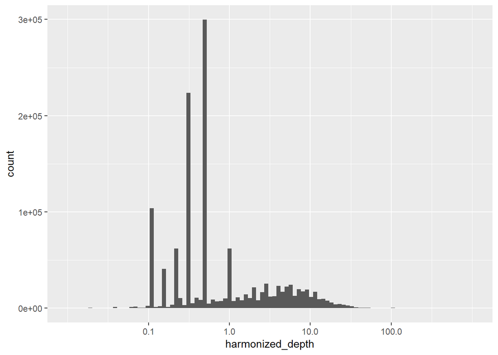

```r
ggplot(tss.depth,aes(x=harmonized_depth)) +
  geom_histogram(bins=100) +
  scale_x_log10(limits=c(0.01,10^3),breaks=c(.1,1,10,100))
```

If we ignore all these additional data streams and simply assume SSC and TSS are generally near surface water samples collected with compatible field sampling and analytical methods. Then we can simply get rid of samples that have nonsensical units.

## TSS Unit Harmonization

### TSS disharmony

As with secchi disk depth, we expect certain units to be associated with total suspended solids or suspended sediment concentration. These include mass per volume measurements like: mg/l, g/l, ug/l and others.

TSS does come with one less obvious parameter which is %. Any sample with a % unit is most commonly a sample where suspended sediments were split into particle size fractions. The relative proportion of clay, silt, and sand can have important impacts on the reflectance properties of water, so this is a useful parameter to keep, though it will require some exploration, using the additional data column that we relabeld as “particle_size.”

#### TSS particle size fractionation

```r
#Select only units for %
tss.p <- tss %>%
  filter(units == '%')

#look at the breakdown of particle sizes
tss.p %>%
  group_by(particle_size) %>%
  summarize(count=n()) %>%
  kable(.,'html',caption='All particle size fractions and their count') %>%
  kable_styling() %>%
  scroll_box(width='600px',height='400px')
```

All particle size fractions and their count

| particle_size | count |
| --- | --- |
| NA | 691986 |
| < 0.001 mm | 11 |
| < 0.002 mm | 1837 |
| < 0.004 mm | 2713 |
| < 0.008 mm | 1565 |
| < 0.016 mm | 2596 |
| < 0.031 mm | 1561 |
| < 0.0625 mm | 22935 |
| < 0.062mm | 172 |
| < 0.09 mm | 86 |
| < 0.125 mm | 3292 |
| < 0.18 mm | 86 |
| < 0.25 mm | 2842 |
| < 0.355 mm | 80 |
| < 0.5 mm | 2075 |
| < 0.71 mm | 19 |
| < 1 mm | 1060 |
| < 1.4 mm | 1 |
| < 16 mm | 1 |
| < 2 mm | 518 |
| < 4 mm | 6 |
| < 8 mm | 1 |
| sands | 996 |
| silts and clays | 998 |

```r
#Keep only the sand fraction data (~50% of the data)
sand.harmonized  <- tss.p %>%
  filter(particle_size %in%  c('< 0.0625 mm','sands')) %>%
  mutate(conversion=NA,
         harmonized_parameter='p.sand',
         harmonized_value=value,
         harmonized_unit='%')
```

#### TSS dropping bad units

Here we will convert all remaining sediment values to units of mg/L and drop any non mass/volume units.

```r
#Make a tss lookup table
tss.lookup <- tibble(units=c('mg/l','g/l','ug/l','ppm'),
                        conversion = c(1,1000,1/1000,1))


unit.disharmony(tss,tss.lookup)
```

The following measurements were dropped because the units do not make sense

| units | count |
| --- | --- |
| NA | 271606 |
| % | 737437 |
| count | 1 |
| g | 313 |
| kg | 29 |
| None | 19 |
| NTU | 1 |
| tons/day | 529 |

### TSS harmony in mg/l

Now we can convert all TSS measurements to untis of ‘mg/l.’ We do need to do one final splitting of the data because there is another parameter name called “Fixed suspended solids.” Fixed suspended solids are essentialy the inorganic component of a sediment sample that remains after kiln drying at 550°F. We will relable these as a harmonized parameter ‘Total inorganic sediment’ or tis.

```r
#Join to the lookup table and harmonize units

tss.tis.harmonized <- tss %>%
  inner_join(tss.lookup,by='units') %>%
  mutate(harmonized_parameter = 'tss',
         harmonized_value=value*conversion,
         harmonized_unit='mg/l') %>%
  #Change harmonized parameter to tis for parameter "fixed suspended solids"
  mutate(harmonized_parameter = ifelse(parameter == 'Fixed suspended solids','tis',harmonized_parameter))

rm(tss,tss.depth,tss.filtered,tss.lookup,tss.p,non.sensical.tss.methods,depth.lookup)
gc()
```

```
##             used   (Mb) gc trigger   (Mb)  max used   (Mb)
## Ncells   1298033   69.4    2359418  126.1   2094961  111.9
## Vcells 174217136 1329.2  454008346 3463.9 434882152 3317.9
```

## TSS SSC empirical check

```r
names(tss.tis.harmonized)
```

```
##  [1] "date"                 "parameter"            "units"
##  [4] "SiteID"               "org"                  "org_id"
##  [7] "time"                 "value"                "sample_method"
## [10] "analytical_method"    "particle_size"        "date_time"
## [13] "media"                "sample_depth"         "sample_depth_unit"
## [16] "fraction"             "status"               "conversion"
## [19] "harmonized_parameter" "harmonized_value"     "harmonized_unit"
```

```r
ssc.tss <- tss.tis.harmonized %>%
  filter(parameter %in% c('Total suspended solids','Suspended Sediment Concentration (SSC)')) %>%
  select(date,date_time,SiteID,parameter,harmonized_value) %>%
  distinct(date_time,SiteID,.keep_all=T) %>%
  spread(key=parameter,value=harmonized_value) %>%
  rename(tss=`Total suspended solids`,ssc=`Suspended Sediment Concentration (SSC)`)

ssc.tss %>%
  filter(!is.na(ssc)) %>%
  summary(.)
```

```
##       date              date_time                      SiteID
##  Min.   :1901-01-01   Min.   :1905-05-30 18:20:00   Length:1062847
##  1st Qu.:1977-09-07   1st Qu.:1977-09-13 13:45:00   Class :character
##  Median :1992-03-04   Median :1992-03-11 17:00:00   Mode  :character
##  Mean   :1990-07-16   Mean   :1990-07-23 04:06:55
##  3rd Qu.:2008-08-14   3rd Qu.:2008-08-16 16:52:30
##  Max.   :2019-03-22   Max.   :2019-03-23 04:55:00
##                       NA's   :1264
##       ssc               tss
##  Min.   :     -2   Min.   : NA
##  1st Qu.:     16   1st Qu.: NA
##  Median :     78   Median : NA
##  Mean   :   1838   Mean   :NaN
##  3rd Qu.:    449   3rd Qu.: NA
##  Max.   :7840000   Max.   : NA
##                    NA's   :1062847
```

# DOC

Dissolved organic carbon (DOC) is a complex series of parameters, methods, and unit combinations. We will not be examining particulate organic carbon, or total organic carbon.

First let’s read in the data.

```r
#Summarize by characteristic name and unit code
doc <- read_feather('1_wqdata/out/wqp/all_raw_doc.feather') %>%
  wqp.renamer(.)
```

```
## [1] "we dropped 69114 samples because the sample medium was not labeled as Water"
```

### DOC sample fraction and sample methods

The water quality portal does not have a category for “Dissolved Organic Carbon,” so we pulled three parameter names that might capture this category. ‘Total Carbon’, ‘Organic Carbon’, and ‘Non-purgeable Organic Carbon (NPOC)’. For our purposes NPOC and Organic Carbon are exchnageable parameter names. In this data, there is a key column that we labeled ‘fraction’, which declares what fraction of the carbon pool is being reported. For purposes of this work, we are only keeping the fraction that indicates dissolved organic carbon, which can include fraction names like ‘Dissolved’ or ‘Filterable.’ The full list of fraction names and parameter names.

```r
doc %>%
  group_by(fraction) %>%
  summarize(count=n()) %>%
  arrange(desc(count)) %>%
  kable(.,'html',caption='All doc sample fraction names and their count') %>%
  kable_styling() %>%
  scroll_box(width='600px',height='400px')
```

All doc sample fraction names and their count

| fraction | count |
| --- | --- |
| Total | 1275941 |
| Dissolved | 681155 |
| Non-Filterable (Particle) | 141307 |
| Suspended | 91299 |
| NA | 3149 |
| Bed Sediment | 2919 |
| Filtered, lab | 2432 |
| Filterable | 2035 |
| Unfiltered | 1753 |
| Filtered, field | 164 |
| Organic | 72 |
| Acid Soluble | 1 |

#### Keeping only Dissolved Fraciton

Here we subset the data to only include the data that we know is the Dissolved Organic Carbon pool. So far this is without regard to differences in analytical method.

```r
doc.fraction.names <- c('Dissolved','Filterable','Filtered, lab','Filtered, field')
doc.dissolved <- doc %>%
  filter(fraction %in% doc.fraction.names)


print(paste('we dropped',nrow(doc)-nrow(doc.dissolved),'samples because they were not labeled as dissolved'))
```

```
## [1] "we dropped 1516441 samples because they were not labeled as dissolved"
```

## DOC methods

Here, we’ll explore method, and unit combinations and trim the data down a lot to keep only the most useful data.

### DOC sample methods

As with TSS we are not going to filter our DOC data by sample method but the table of sample methods are provided here.

```r
sample.kable(doc.dissolved)
```

All sample methods and their count

| sample_method | count |
| --- | --- |
| Surface | 118938 |
| USGS | 116395 |
| Dissolved Nutrient Sample Filtration & Collection T | 65866 |
| Grab Sample Collected With A Stainless Bucket | 42075 |
| SJR-SOP | 27046 |
| Equal width increment (ewi) | 26461 |
| Dissolved Nutrient Sample Filtration & Collection | 22921 |
| Dissolved Nutrient Sample Filtration & Collection B | 22147 |
| Multiple verticals | 21818 |
| Grab | 19975 |
| Grab Sampling | 18817 |
| Generic SJRWMD Sample Collection Procedure | 18508 |
| Grab sample (dip) | 15081 |
| G | 9790 |
| Standard Routine Sample Collection | 8555 |
| GRAB | 8166 |
| Water_Grab | 6496 |
| Land Collections Directly from Water Source | 5248 |
| Unknown | 5092 |
| Grab Sample Collected With A Water Bottle | 4578 |
| Dissolved Nutrient Sample Filtration & Collection A | 4028 |
| Equal discharge increment (edi) | 3967 |
| Point sample | 3596 |
| Land Station Collection from Bridge | 3462 |
| Boat Station Collections | 3456 |
| Grab sample. Submerge and fill a water sampling vessel, or sample directly into the sample bottle provided by the an… | 3299 |
| LEGACY | 3215 |
| ISU Lake Sample Collection Procedure | 3181 |
| Dissolved Nutrient Sample Filtration & Collection K | 3050 |
| Automated sample collection | 2517 |

[output cut: 187 more lines]

### DOC analytical method

After removing the non “dissolved” fraction of carbon observations we are left with ~ 650,000 samples. Here we will remove analytical methods that explicitly do not make sense. As with TSS we will keep samples with analytical methods labeled as NA, assuming that they were done in a way that is exchangeable with other methods. This is a potentially erroneous assumption.

```r
analytical.kable(doc.dissolved)
```

All analytical methods and their count

| analytical_method | count |
| --- | --- |
| NA | 103992 |
| Total Organic Carbon by Combustion | 81593 |
| 5310 B ~ Total Organic Carbon by Combustion-Infrared Method | 76880 |
| analyticDOC_101 | 47422 |
| analyticDOC_102 | 42339 |
| DOC, 0.45u silver, persulfate IR | 38218 |
| WET OXIDATION METHOD | 33576 |
| DOC,0.45um cap,acid,persulfateIR | 31831 |
| DOC, UV/persulfate/IR (USGS-NYL) | 31269 |
| 5310 C ~ Total Organic Carbon in Water- Ultraviolet Oxidation Method | 28733 |
| analyticDOC_L01N | 28251 |
| UV OR HEATED PERSULFATE OXIDATION | 26096 |
| Low Level Total Organic Carbon in Water | 17857 |
| DOC, 0.7um GFF,acid,persulfateIR | 17544 |
| 5310 B ~ Total Organic Carbon by High-Temperature Combustion Method | 16969 |
| DOC, persulfate oxidation & IR | 7734 |
| DOC, UV/persulfate (NYWSC; ALSC) | 4581 |
| SM5310B | 4502 |
| Organic Carbon in Water | 4382 |
| DOC, wf, 0.45 um cap, combust IR | 3803 |
| Unspecified Standard Grab Sample Procedure | 3215 |
| Dissolved organic carbon by Teledyne-Tekmar Phoenix 8000 TOC Analyzer | 2951 |
| Organic-C, combustion-IR method | 2727 |
| SM 5310 B | 2723 |
| DOC, EPA method | 2386 |
| C | 2214 |
| EPA 415.1M | 1769 |
| Elemental Analysis Isotope Ratio Mass Spectometry | 1557 |
| CARBON, DISSOLVED ORGANIC (MG/L AS C) | 1392 |
| DOC, wf, 0.7 um GFF, combust IR | 1309 |

[output cut: 77 more lines]

#### DOC removing nonsensical analytical methods

```r
doc.nonsense.methods <- doc.dissolved %>%
  filter(grepl("Oxygen|Nitrogen|Ammonia|Metals|E. coli|Anion|Cation|Phosphorus|Silica|PH|HARDNESS|Nutrient|Turbidity|Nitrate|Conductance|Alkalinity|Chlorophyll|Solids",analytical_method,ignore.case=T)) %>%
  filter(analytical_method != 'Temperature')


doc.filtered <- doc.dissolved %>%
  filter(!analytical_method %in% doc.nonsense.methods$analytical_method)

print(paste('We dropped', round(nrow(doc.nonsense.methods)/nrow(doc)*100,2),'% of samples, because the method used did not make sense. These methods are:'))
```

```
## [1] "We dropped 0.14 % of samples, because the method used did not make sense. These methods are:"
```

```r
p(unique(doc.nonsense.methods$analytical_method),wrap='',sep=' - ')
```

```
## [1] "BIOCHEMICAL OXYGEN DEMAND, 5-DAY - Dissolved Organic Carbon by Infrared Absorption Spectrophotometry USGS TWRI 1983 - Nitrogen and Phosphorus Pesticides - 200.7 W  ~ Metals in Water by ICP-AES - 10200 H ~ Chlorophyll a-b-c Determination - pH - 2540 D ~ Total Suspended Solids in Water - 2540 …
```

## DOC Units

As with TSS we generally expect DOC units to be in units of mass per unit volume, but we have many more possible variations of methods used to extract DOC values.

```r
unit.kable(doc.filtered)
```

All parameter and unit combinations

| units | count |
| --- | --- |
| mg/l | 670986 |
| NA | 9390 |
| ppm | 1104 |
| % | 521 |
| None | 510 |
| ug/l | 148 |

Wow that is great. The vast majority of data is in a sensible unit (mg/L). We’ll harmonize the remaining mass/volume units (ppm/ug/L) and drop the NAs and % units. Looks like sampling by `sample fraction` column cuts out a lot of the potential disharmony in units.

### DOC unit disharmony

```r
#Setup a lookup table so that final units are all in mg/L.
doc.lookup <- tibble(units=c('mg/l','ppm','ug/l'),
                        conversion = c(1,1,.001))

unit.disharmony(doc.filtered,doc.lookup)
```

The following measurements were dropped because the units do not make sense

| units | count |
| --- | --- |
| NA | 9390 |
| % | 521 |
| None | 510 |

## DOC harmony

The final step. Convert all convertable units to mg/l!

```r
doc.harmonized <- doc.filtered %>%
  inner_join(doc.lookup,by='units') %>%
  mutate(harmonized_parameter = 'doc',
         harmonized_value=value*conversion,
         harmonized_unit='mg/L')

rm(doc,doc.dissolved,doc.filtered,doc.lookup,doc.nonsense.methods)
```

# Chlorophyll

Chlorophyll concentration is a good proxy for algal biomass, but it may be the hardest parameter to harmonize because of a large array of diverse methods and measurements. Fist let’s drop measurements that were not water samples (benthic chlorophyll)

```r
#Read in the raw data from '1_wqdata/out'
chl <- read_feather('1_wqdata/out/wqp/all_raw_chlorophyll.feather') %>%
  wqp.renamer()
```

```
## [1] "we dropped 31916 samples because the sample medium was not labeled as Water"
```

## Chlorophyll a only

Here we are reducing the harmonization difficulty associated with chlorphyll by only keeping Chlorophyll a measurements, which is by far the most common measurement. But let’s first look at all the various chlorophyll names we pulled down from the water quality portal.

```r
chl %>%
   group_by(parameter) %>%
   summarize(count=n()) %>%
   arrange(desc(count)) %>%
   kable(.,'html',caption='All chlorophyll parameter names and their count') %>%
   kable_styling() %>%
   scroll_box(width='600px',height='400px')
```

All chlorophyll parameter names and their count

| parameter | count |
| --- | --- |
| Chlorophyll a | 1443742 |
| Chlorophyll a (probe relative fluorescence) | 635802 |
| Chlorophyll a, corrected for pheophytin | 549818 |
| Chlorophyll b | 315572 |
| Chlorophyll a, uncorrected for pheophytin | 298326 |
| Chlorophyll c | 263010 |
| Chlorophyll | 158439 |
| Chlorophyll a (probe) | 142934 |
| Chlorophyll/Pheophytin ratio | 93517 |
| Chlorophyll a, free of pheophytin | 57245 |
| Chlorophyll a - Phytoplankton (suspended) | 2860 |
| Chlorophyll a - Periphyton (attached) | 2645 |

One key parameter we are deciding to drop here is the Chl a, uncorrected for pheophytin. Pheophytin is a biproduct of chlorophyll degradation that can be generated by the processes used to extract chlorophyll from samples. Samples that do not correct for pheophytin can consistently underestimate in situ chlorophyll concentration, so we are choosing to drop these > 250,000 observations in addition to other non-chlorophyll a samples

### Chlorophyll a parameter disharmony

We are dropping the below parameter names

```r
chl.a.names <- c('Chlorophyll a','Chlorophyll a (probe relative fluorescence)','Chlorophyll a, corrected for pheophytin','Chlorophyll a (probe)','Chlorophyll a, free of pheophytin', 'Chlorophyll a - Phytoplankton (suspended)')

chl %>%
  filter(!parameter %in% chl.a.names) %>%
  group_by(parameter) %>%
  summarize(count=n()) %>%
  kable(.,'html',caption='All dropped chlorophyll parameter names and their count') %>%
  kable_styling() %>%
  scroll_box(width='600px',height='400px')
```

All dropped chlorophyll parameter names and their count

| parameter | count |
| --- | --- |
| Chlorophyll | 158439 |
| Chlorophyll a - Periphyton (attached) | 2645 |
| Chlorophyll a, uncorrected for pheophytin | 298326 |
| Chlorophyll b | 315572 |
| Chlorophyll c | 263010 |
| Chlorophyll/Pheophytin ratio | 93517 |

### Chlorophyll a keep

```r
chl.a <- chl %>%
  filter(parameter %in% chl.a.names)
```

## Chlorophyll a sample fraction

Now that we are only keeping the chlorophyll a fraction, we can start removing disharmony in the sample fraction, analytical method, and units categories. We’ll start with the sample fraction

### Chlorophyll a all fractions

```r
chl.a %>%
   group_by(fraction) %>%
   summarize(count=n()) %>%
   arrange(desc(count)) %>%
   kable(.,'html',caption='All chlorophyll sample fractions and their count') %>%
   kable_styling() %>%
   scroll_box(width='600px',height='400px')
```

All chlorophyll sample fractions and their count

| fraction | count |
| --- | --- |
| Total | 1258059 |
| NA | 1036790 |
| Filtered, lab | 210802 |
| Non-Filterable (Particle) | 188070 |
| Filterable | 85718 |
| None | 24664 |
| Suspended | 11560 |
| Non-filterable | 9534 |
| Dissolved | 4089 |
| Extractable | 2157 |
| Unfiltered | 765 |
| Comb Available | 146 |
| Filtered, field | 41 |
| <Blank> | 4 |
| Acid Soluble | 2 |

### Chlorophyll fraction keep

```r
chl.particles <- c('Non-Filterable (Particle)','Suspended','Non-filterable','<Blank>','Acid Soluble')

chl.a.fraction <- chl.a %>%
  filter(!fraction %in% chl.particles)
```

## Chlorophyll a Methods

### Chlorophyll a sample methods

As with all other parameters we are not filtering by sample method

```r
sample.kable(chl.a.fraction)
```

All sample methods and their count

| sample_method | count |
| --- | --- |
| LG301 | 298183 |
| NA | 257793 |
| GRAB | 256296 |
| Surface | 203380 |
| Lake surface 2m depth-integrated sampling. Lower a 2-meter-long, 2-inch-diameter PVC pipe vertically into the water, … | 96924 |
| Unknown | 95641 |
| USGS | 92383 |
| SJR-SOP | 91898 |
| Grab | 65195 |
| G | 62699 |
| Grab sample. Submerge and fill a water sampling vessel, or sample directly into the sample bottle provided by the an… | 55502 |
| Shallow Water Continuous Monitoring in Tidal Potomac | 49169 |
| Garden hose composite | 41212 |
| WATER GRAB SAMPLE | 40653 |
| in situ | 38372 |
| SOP | 32905 |
| LEGACY | 32746 |
| ADEM SOPs-2000 Series-Surface Water | 31759 |
| SOP-1 | 31250 |
| Towed CTD recording both up and down | 30239 |
| Ambient Water Quality Monitoring QAPP and SOP | 28704 |
| Grab Sample Collected With A Stainless Bucket | 27152 |
| FL DEP Field Sample Collection DEP SOP 01-001 | 23328 |
| Grab Sample | 21390 |
| Lake depth point sampling. Lake water is sampled at a discrete depth in the water column using a vertical Kemmerer- … | 21330 |
| SWFWMD SOP’s for the Collection of Water Quality Samples | 18958 |
| UHL001 | 17656 |
| Generic SJRWMD Sample Collection Procedure | 16625 |
| Standard Routine Sample Collection | 14899 |
| SP-001 | 14488 |

[output cut: 385 more lines]

### Chlorophyll a analytical methods

```r
analytical.kable(chl.a.fraction)
```

All analytical methods and their count

| analytical_method | count |
| --- | --- |
| NA | 901037 |
| 10200 H ~ Chlorophyll a-b-c Determination | 502210 |
| Operating the Seabird CTD | 378767 |
| In-Vitro Determination of Chlorophyll | 218487 |
| MONOCHROMATIC; SPECTROPHOTOMETRIC | 192691 |
| Wet Labs WETStar Fluorometer | 127918 |
| CONTACT VADEQ FOR DETAILS | 49161 |
| Analysis of Chlorophyll in Periphyton and Plankton | 30317 |
| CHLOROPHYLL-A UG/L SPECTROPHOTOMETRIC ACID. METH. | 24445 |
| 10200 H 3 ~ Chlorophyll a-b-c Determination by fluorometer | 19214 |
| Chlorophyll, phytoplankton, HPLC | 14623 |
| Not Available | 12538 |
| Standard Methods for the Examination of Water and Wastewater | 11416 |
| Plant pigments, sonication & 445 | 11384 |
| UNKOWN | 9710 |
| FLUOROMETRIC; IN-VITRO CHLOROPHYLL A | 8867 |
| 10200 H 2 ~ Chlorophyll a-b-c Determination by spectrophotometer | 8722 |
| FLUOROMETIC CHLOROPHYLL USING PROBE | 7397 |
| 10200 G ~ Zooplankton Counting Techniques | 6565 |
| Chlorophyll a, corrected for pheophytin | 5930 |
| Chlorophyll a | 5738 |
| USEPA 445 | 4340 |
| Chlorophyll a,phyto,fluorometric | 4290 |
| SM 10200 H-2b | 3471 |
| Unspecified Standard Grab Sample Procedure | 3254 |
| High Performance Liquid Chromatography | 3087 |
| Chlorophyll a, phytoplankton | 3035 |
| YSI6025 | 3001 |
| Chlorophylls and Pheopigments in Phytoplankton by Spectrophotometry | 2883 |
| QA Plan #900456 | 2816 |

[output cut: 104 more lines]

#### Chlorophyll a removing nonsensical analytical methods

There are quite a few different analytical methods for chlorophyll analysis. Unfortunately the most common category is NA. As with previous parameters we can use this category to simply remove clearly non-sensical methods and keep all others including NA and blank.

```r
chl.a.nonsense.methods <- chl.a.fraction %>%
  filter(grepl("Oxygen|Nitrogen|Ammonia|Metals|Anion|Cation|Phosphorus|Silica|HARDNESS|Nutrient|Turbidity|Nitrate|Conductance|Alkalinity|Solids",analytical_method,ignore.case=T)) %>%
  filter(analytical_method != 'Temperature',
         analytical_method != 'PH')

chl.a.filtered <- chl.a.fraction %>%
  filter(!analytical_method %in% chl.a.nonsense.methods$analytical_method)

print(paste('We dropped', round(nrow(chl.a.nonsense.methods)/nrow(chl)*100,2),'% of samples, because the method used did not make sense. These methods are:'))
```

```
## [1] "We dropped 0.35 % of samples, because the method used did not make sense. These methods are:"
```

```r
p(unique(chl.a.nonsense.methods$analytical_method),wrap='',sep=' - ')
```

```
## [1] "Plant pigments, sonication & 445 - Organophosphorus Compounds by Gas Chromatography: Capillary Column Technique - Nitrite Nitrogen by Spectophotometry - Conductance - Nutrient analyses - Phosphorus by Colorimetry - Turbidity by Nephelometry - 5 Day Biochemical Oxygen Demand - Alkalinity in W…
```

## Chlorophyll a units

As with TSS and DOC we generally expect Chlorophyll a units to be in units of mass per unit volume.

```r
unit.kable(chl.a.filtered)
```

All parameter and unit combinations

| units | count |
| --- | --- |
| ug/l | 1928434 |
| mg/m3 | 467632 |
| NA | 70966 |
| % | 49161 |
| volts | 40113 |
| ppb | 26985 |
| mg/m2 | 9500 |
| mg/l | 7629 |
| None | 5782 |
| RFU | 1546 |
| ppm | 804 |
| umol/m2/s | 218 |
| mg/cm2 | 142 |
| ug/cm2 | 101 |
| IVFU | 90 |
| mg/ml | 74 |
| g/m2 | 69 |
| mg/cm3 | 66 |
| mg | 54 |
| ug/ml | 46 |
| NTU | 2 |
| ng/cm2 | 1 |

Here again, the majority of data is in a sensible unit (ug/L). We’ll harmonize the remaining mass/volume units (ppm,mg/L) and drop the NAs and % units. We’ll harmonize Chlorophyll a to the most common unit in the data (ug/L).

### Chlorophyll a unit disharmony

```r
#Setup a lookup table so that final units are all in mg/L.
chl.lookup <- tibble(units=c('mg/l','ppm','ug/l','mg/m3','ppb','mg/cm3','ug/ml','mg/ml'),
                        conversion = c(1000,1000,1,1,1,1000000,1000,1000000))

unit.disharmony(chl.a.filtered,chl.lookup)
```

The following measurements were dropped because the units do not make sense

| units | count |
| --- | --- |
| NA | 70966 |
| % | 49161 |
| g/m2 | 69 |
| IVFU | 90 |
| mg | 54 |
| mg/cm2 | 142 |
| mg/m2 | 9500 |
| ng/cm2 | 1 |
| None | 5782 |
| NTU | 2 |
| RFU | 1546 |
| ug/cm2 | 101 |
| umol/m2/s | 218 |
| volts | 40113 |

## Chl harmony

```r
chl.a.harmonized <- chl.a.filtered %>%
  inner_join(chl.lookup,by='units') %>%
  mutate(harmonized_parameter = 'chl.a',
         harmonized_value=value*conversion,
         harmonized_unit='ug/L')


rm(chl,chl.a,chl.a.filtered,chla.a.fraction,chl.a.nonsense.methods,chl.loookup)
```

Another call to gc() to clear memory again

```r
gc()
```

```
##             used   (Mb) gc trigger   (Mb)  max used   (Mb)
## Ncells   1332782   71.2    5428575  290.0   7329206  391.5
## Vcells 299992875 2288.8  544890015 4157.2 472202068 3602.7
```

# CDOM

```r
#Summarize by characteristic name and unit code
cdom <- read_feather('1_wqdata/out/wqp/all_raw_cdom.feather') %>%
  wqp.renamer(.)
```

```
## [1] "we dropped 22 samples because the sample medium was not labeled as Water"
```

### CDOM sample fraction and sample methods

The water quality portal has a single call for CDOM: `'Colored dissolved organic matter (CDOM)'`. Fortunately this name includes some key metrics, the parameter is the dissolved fraction of the carbon pool and the colored portion. Still, we need to do some filtering based on analytical method.

## CDOM methods

Here, we’ll explore method, and unit combinations and trim the data down a lot to keep only the most useful data.

### CDOM sample methods

As with TSS we are not going to filter our CDOM data by sample method but the table of sample methods are provided here.

```r
sample.kable(cdom)
```

All sample methods and their count

| sample_method | count |
| --- | --- |
| Chesapeake Bay Program | 855 |
| USGS | 432 |
| Grab sample (dip) | 353 |
| Grab Sample Collected With A Stainless Bucket | 312 |
| Multiple verticals | 285 |
| in situ | 260 |
| Equal width increment (ewi) | 249 |
| Single vertical | 206 |
| Point sample | 156 |
| Grab Sample | 154 |
| Passive diffusion, organic-free deionized water | 18 |
| Grab Sample Collected With A Water Bottle | 13 |
| Multiple verticals, non-isokinetic, equal widths and transit rate | 13 |
| Van Dorn sampler | 6 |
| Peristaltic pump | 5 |
| Open-top bailer | 4 |
| Weighted bottle | 4 |
| SuspSed; Pumping - stream sample using a pumping mechanism | 3 |
| Other | 1 |

### DOC analytical method

```r
analytical.kable(cdom)
```

All analytical methods and their count

| analytical_method | count |
| --- | --- |
| NA | 1674 |
| CHROMOPHORIC DISSOLVED ORGANIC MATTER | 855 |
| Turner Designs Trilogy Fluorometer with CDOM specific excitation/emission filters for monitoring CDOM in natural waters | 325 |
| YSI EXO fluorometer, 365/480 nm | 141 |
| YSI EXO, 365/480/80 nm | 113 |
| NASA/TM-2003-211621/Rev4-Vol.IV | 96 |
| Turner Designs fluoro.,365/470nm | 67 |
| CDOM absorption (440nm) | 58 |

## CDOM Units

```r
unit.kable(cdom)
```

All parameter and unit combinations

| units | count |
| --- | --- |
| RFU | 1111 |
| ug/l QSE | 945 |
| None | 855 |
| m | 284 |
| ug/l | 130 |
| NA | 4 |

# Bind and save the harmonized data

At the end of all this harmonization we want a data frame with parameter columns that hold the final harmonized values, along with a date, lat, long, and siteid. But first we need to do some more quality control on the full, harmonized dataset. This additional data munging can be found in the script `2_combined_wqp_munge.Rmd`

```r
#Downstream code can't handle the size of the single TSS data file so we will split that into a few separate datasets  instead of one

#First just the TIS data
tis.harmonized <- tss.tis.harmonized %>%
  filter(harmonized_parameter=='tis')

#Add an index to help with splitting
tss.harmonized <- tss.tis.harmonized %>%
  filter(harmonized_parameter=='tss') %>%
  arrange(SiteID,date) %>%
  mutate(index=1:nrow(.))



#Bind all the harmonized data together
harmonized.datasets <- list(chl.a.harmonized,doc.harmonized,tis.harmonized,tss.harmonized,sand.harmonized,secchi.harmonized)

h.names <- c('chl.a','doc','tis','tss','sand','secchi')
```

# Check for observations at a ridiculous depth

```r
#Before exporting the harmonized data we can do one more quality check
singular.harmony <- map_dfr(harmonized.datasets,rbind)

has.depth <- singular.harmony %>%
  filter(!is.na(sample_depth))

print(paste('We would lose',100*round(1-(nrow(has.depth)/nrow(singular.harmony)),3),'% of samples if we kept only observations that have sample depth recorded'))
```

```
## [1] "We would lose 58 % of samples if we kept only observations that have sample depth recorded"
```

```r
depth.lookup <- tibble(sample_depth_unit=c('cm','feet','ft','in','m','meters','None'),
                       depth_conversion=c(1/100,.3048,.3048,0.0254,1,1,NA))

shallow.depth <- has.depth %>%
  left_join(depth.lookup,by='sample_depth_unit') %>%
  mutate(harmonized_depth = abs(sample_depth)*depth_conversion) %>% #some depth is recorded as a negative value

  filter(harmonized_depth < 100)


summary(shallow.depth$harmonized_depth)
```

```
##    Min. 1st Qu.  Median    Mean 3rd Qu.    Max.
##   0.000   0.100   0.500   3.096   1.200  99.985
```

```r
print(paste('We lose',round((nrow(has.depth)-nrow(shallow.depth))/nrow(singular.harmony)*100,3),' % of samples by restricting data to less than 100m'))
```

```
## [1] "We lose 1.959  % of samples by restricting data to less than 100m"
```

```r
#Remove extraneous columns
extraneous <- function(df){
  df <- df %>%
    mutate(index = 1:nrow(.)) %>%
    filter(!is.na(harmonized_value)) %>%
    ungroup() %>%
    left_join(depth.lookup,by='sample_depth_unit') %>%
    mutate(harmonized_depth = abs(sample_depth)*depth_conversion) %>%
    filter(harmonized_depth < 100 | is.na(harmonized_depth)) %>%
    #Remove extraneous columns
    dplyr::select(-units,-org,-org_id,-sample_method,
                  -sample_depth,-sample_depth_unit,
                  -particle_size,-media,-fraction,
                  -status,-conversion)
}


#Remove columns and save
for(i in 1:length(harmonized.datasets)){
  print(i)
  dat <- extraneous(harmonized.datasets[[i]])
  write_feather(dat,
                path=paste0('1_wqdata/tmp/harmonized/',
                            h.names[i],'_harmony.feather'))
}
```

```
## [1] 1
## [1] 2
## [1] 3
## [1] 4
## [1] 5
## [1] 6
```

```r
# tss.cleaned <- tss.harmonized %>%
#   extraneous(.)
# write_feather(tss.cleaned,path=paste0('1_wqdata/tmp/harmonized/',
#                             'tss','_harmony.feather'))
```